# RESETageing training school

## Factors - creation

- Factors can represent categories, important for statistics or graphics

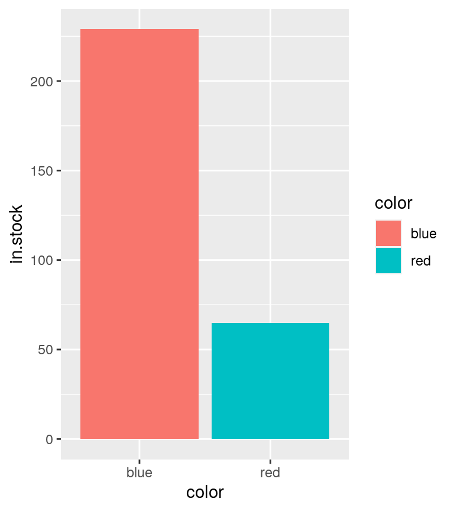

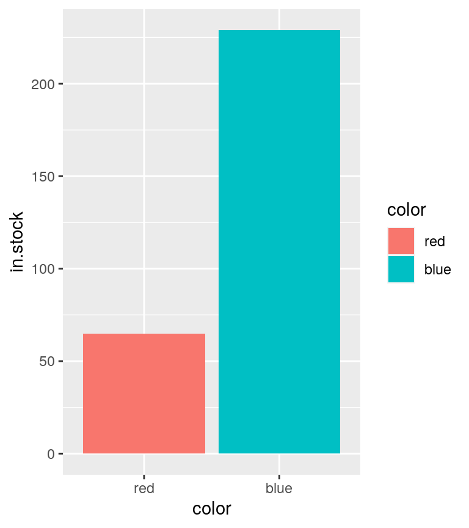

## Functions

You already learned a lot of basic functions on-the-fly

- `c()`, `rep()`
- `str()`, `typeof()`
- `length()`, `dim()`
- `sort()`, `rev()`, `unique()`
- `list()`, `matrix()`, `t()`, `data.frame()`
- `as.double()`, `as.character()`, `sum()`

The values that are given to functions are called **arguments**

You can write, save, and use your **own functions**. (not needed here)

```r
> my_sum <- function(v){
+    sum(v) # local scope
+ }
>
> v <- c(4,5,6) # global scope
> res <- my_sum(c(1,2,3))
> res
## [1] 6
```

## Feedback poll

multiple choice, two questions

http://etc.ch/XtV8

## Exercise 1

- How many yellow fruits do we currently have in stock?

```r
> vf <- c("apple","banana","kiwifruit","strawberry","orange","lemmon")
> vc <- c("green","yellow","brown","red","orange","yellow")
> df <- data.frame(fruit = vf, color = vc)
> df$in.stock <- c(25,40,33,0,12,156)
```

Solution:

```r
> df[df$color == "yellow", ]                  # extract rows with yellow fruits
##    fruit  color in.stock
## 2 banana yellow       40
## 6 lemmon yellow      156
>
> df[df$color == "yellow", "in.stock"]        # only display the column in.stock, note: it is a vector
## [1]  40 156
>
> sum(df[df$color == "yellow", "in.stock"])   # sum-up the returned in.stock values
## [1] 196
```

## Touching real data

## Get data into Galaxy

[figure not shown]

## Get data into Galaxy

[figure not shown]

## Get data into Galaxy

[figure not shown]

## Get data into Galaxy

[figure not shown]

## Get data into Galaxy

[figure not shown]

## Get data into Galaxy IE RStudio

- Please create a new sub directory in your working directory called `data`
- Use `gx_get()` to fetch data by its history ID into `/import` directory
- Move the files from `/import` to your current working directory

```r
> gx_get(2) # please adapt according to your Galaxy history!
> gx_get(3)
> file.rename(from = "/import/2",  to = "data/data_animals.csv")
> file.rename(from = "/import/3",  to = "data/deg_analysis.xls")
```

## Import data tables

```r
> animals <- read.table(file = "data/data_animals.csv", sep = ",", header = TRUE)
> # use "\\t" in case of a tab-separated table
> # optional: use argument stringsAsFactors=TRUE <- default depends on the R version (FALSE since R 4.X)
>
> animals
##     animal color size
## 1 elephant  grey  300
## 2   rabbit white   30
## 3    snake green  100
## 4      cow brown  130
## 5    horse black  150
## 6      dog brown   70
## 7     frog   red    5
>
> colnames(animals)
## [1] "animal" "color"  "size"
>
> summary(animals)
##     animal             color                size
##  Length:7           Length:7           Min.   :  5.0
##  Class :character   Class :character   1st Qu.: 50.0
##  Mode  :character   Mode  :character   Median :100.0
##                                        Mean   :112.1
##                                        3rd Qu.:140.0
##                                        Max.   :300.0
```

## Simple graphics

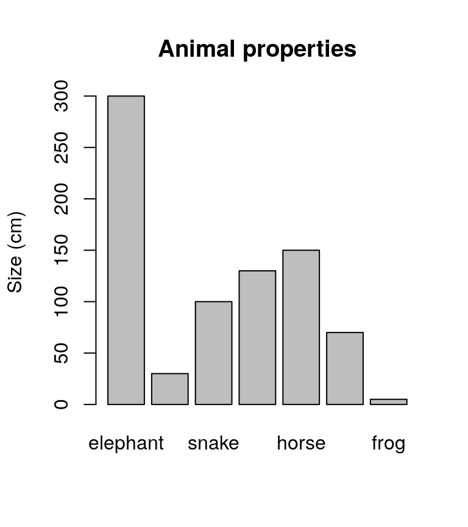

```r
> barplot(animals$size,
+   names.arg=animals$animal,
+   main="Animal properties",
+   ylab="Size (cm)")
```

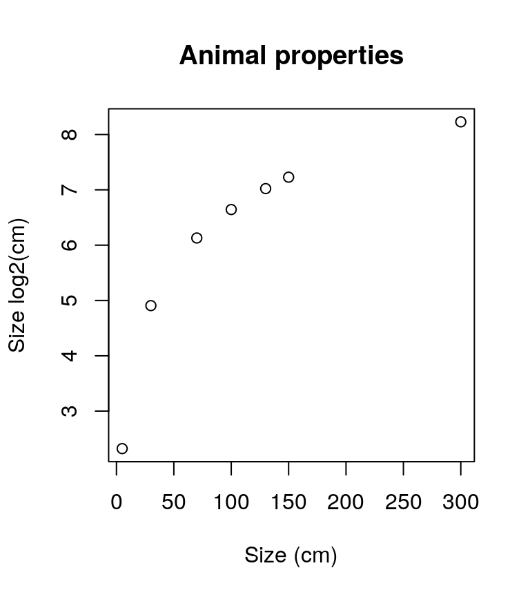

```r
> plot(animals$size,log2(animals$size),
+   names.arg=animals$animal,
+   main="Animal properties",
+   ylab="Size log2(cm)", xlab="Size (cm)")
```

## Simple graphics

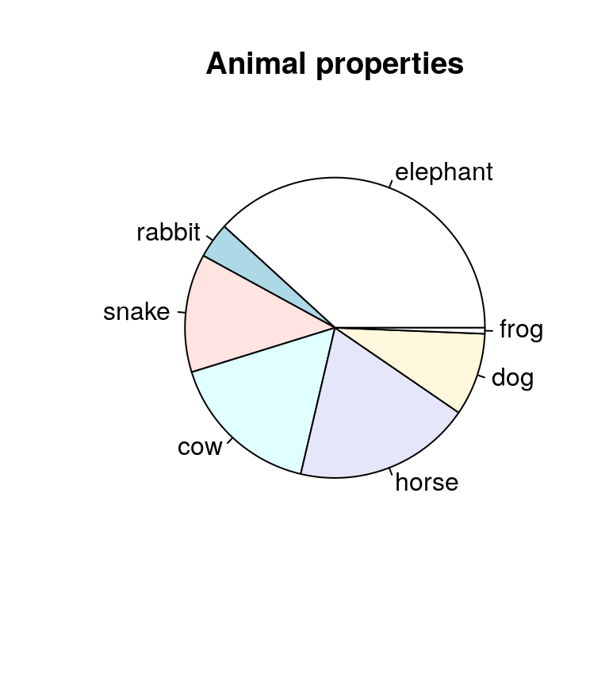

```r
> pie(animals$size,
+   labels=animals$animal,
+   main="Animal properties")
```

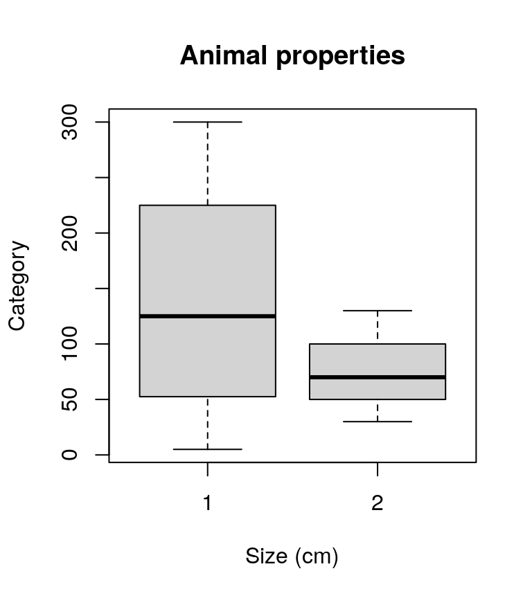

```r
> animals$category <- c(1,2,1,2,1,2,1)
> boxplot(size~category,animals,
+   main="Animal properties",
+   ylab="Category", xlab="Size (cm)")
```

## Packages

- R packages are collections of functions and data sets developed by the community.
- Packages increase the power of R by improving existing base R functionalities, or by adding new ones.
- Large collections (repositories) of packages are [CRAN](https://cran.r-project.org) and [Bioconductor](https://bioconductor.org).
- The methods to install packages from there slightly differ, so here are both commands:

**DO NOT RUN NOW!**

```r
> # CRAN package installation command
> install.packages(c("pheatmap","ggplot2","tidyr","readxl"))
>
> # Bioconductor package installation command
> install.packages("BiocManager")
> BiocManager::install("DESeq2")
```

## Import Excel tables

- We learned before, how to read a `.csv` file using the base R function `read.table()`.
- Base R has **no** function to read Excel files. **Fortunately, someone created a package for it!**

Install the required package

```r
> install.packages("readxl")
```

Load the required package

```r
> library("readxl")
> help(package = "readxl")
```

Import Excel tables

```r
> # run the function "read_excel" from the package "readxl"
> deg.df <- as.data.frame(read_excel(path = "data/deg_analysis.xls"))
> # handles xls and xlsx
> str(deg.df)
## 'data.frame':    23020 obs. of  10 variables:
##  $ id            : chr  "WBGene00000001" "WBGene00000002" "WBGene00000003" "WBGene00000004" ...
##  $ symbol        : chr  "aap-1" "aat-1" "aat-2" "aat-3" ...
##  $ control_1     : num  3857 153 307 1510 102 ...
##  $ control_2     : num  3612 159 325 1642 118 ...
##  $ control_3     : num  3941 137 313 1570 101 ...
##  $ ko_1          : num  4261 194 290 1133 133 ...
##  $ ko_2          : num  4022 182 286 1141 125 ...
##  $ ko_3          : num  3909 179 343 1304 131 ...
##  $ log2FoldChange: num  0.092 0.2653 -0.0384 -0.3799 0.2328 ...
##  $ padj          : num  0.44936 0.1773 0.85781 0.00105 0.29895 ...
```

## The DEG data set in `deg.df`

- Gene expression analysis using RNA-seq in the worm *C. elegans* (see columns `id` & `symbol`)
- 6 biological replicates: 3 controls / 3 with knock-out of a target gene (`control_` & `ko_`)
- Differential expression statistics with DESeq2 (`log2FoldChange` & `padj`)
- Interpretation: `log2FoldChange > 0` up-regulation in KO | `log2FoldChange < 0` down-reg. in KO

```r
> head(deg.df) # print the first 6 rows of our data frame
##               id symbol control_1 control_2 control_3      ko_1      ko_2
## 1 WBGene00000001  aap-1 3856.5403 3612.0591 3940.8629 4261.4508 4022.4646
## 2 WBGene00000002  aat-1  153.4461  158.6615  137.2238  194.0029  182.1178
## 3 WBGene00000003  aat-2  306.8922  325.3565  313.0735  289.9021  285.7078
## 4 WBGene00000004  aat-3 1509.7808 1641.8451 1570.4496 1133.1535 1141.1603
## 5 WBGene00000005  aat-4  101.9397  118.4940  100.6308  133.3770  125.3104
## 6 WBGene00000006  aat-5  152.3730  135.5652  122.9931  123.4564  122.8042
##        ko_3 log2FoldChange        padj
## 1 3909.0812     0.09200015 0.449357936
## 2  179.2724     0.26532116 0.177298454
## 3  342.5046    -0.03839756 0.857813776
## 4 1303.9706    -0.37988531 0.001045972
## 5  131.1519     0.23276302 0.298954693
## 6  125.4907    -0.12156660 0.618089625
```

## Feedback poll

multiple choice, two questions

http://etc.ch/XtV8

## Exercise 2 - Solution

```r
> na.df <- deg.df[! is.na(deg.df$padj) , ]
> sig <- na.df$padj <= 0.05
> sig.n <- sum(sig)
>
> sig.df <- data.frame(
+   reads=c(na.df$control_1[sig],na.df$ko_1[sig]),
+   sample=c(rep("control_1",sig.n),rep("ko_1",sig.n))
+ )
>
> sig.df$reads = log2(sig.df$reads)
>
> head(sig.df, n=4)
##       reads    sample
## 1 10.560123 control_1
## 2 10.975161 control_1
## 3  7.731073 control_1
## 4  8.892880 control_1
>
> tail(sig.df, n=4)
##          reads sample
## 4945  6.290250   ko_1
## 4946  7.541382   ko_1
## 4947  7.833990   ko_1
## 4948 11.006236   ko_1
```

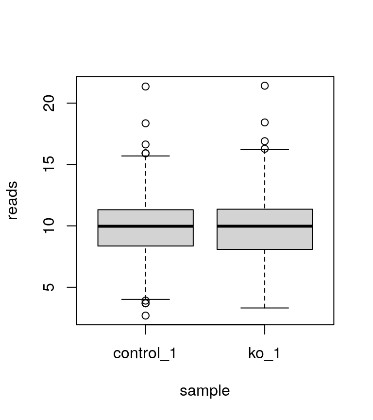

```r
> boxplot(reads~sample,sig.df)
```

## Exercise 2 - Solution

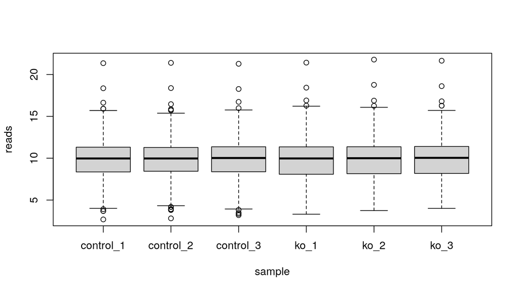

```r
> log2(na.df[1,3:8])
##   control_1 control_2 control_3     ko_1     ko_2     ko_3
## 1  11.91309  11.81861   11.9443 12.05713 11.97386 11.93261
> library("tidyr")
> sig.df <- pivot_longer(log2(na.df[sig,3:8]), cols= 1:6, names_to = "sample", values_to = "reads")
> boxplot(reads~sample,sig.df)
```

## The graphics package ggplot2

- **ggplot2** is a system for programmatically creating graphics, based on “The Grammar of Graphics”.
- To operate, it requires
  - A full data frame
  - An aesthetics which defines how to map data frame columns to axes
  - The graphical primitives to use

`ggplot(dataframe, aes()) + geom_point()`

Load the package into the session:

```r
> library("ggplot2")
```

Documentation: https://ggplot2.tidyverse.org/index.html

Cheat sheet: https://github.com/rstudio/cheatsheets/blob/master/data-visualization-2.1.pdf

## Scatter plot

Inspect the correlation of expression values between two samples.

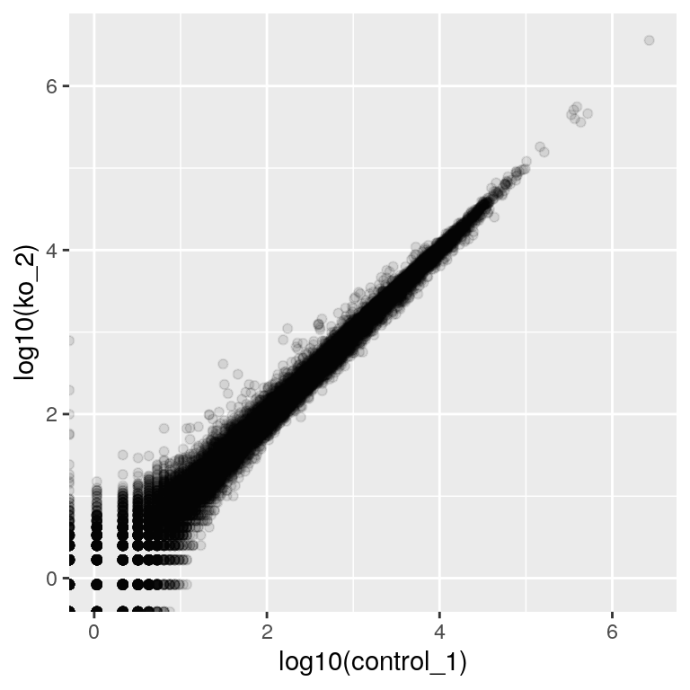

```r
> ggplot(deg.df, aes(x = log10(control_1), y = log10(ko_2))) + geom_point(alpha = 0.1)
```

## Volcano plot

A volcano plot displays the relation of expression strength (`log2FoldChange`) and significance (`padj`)

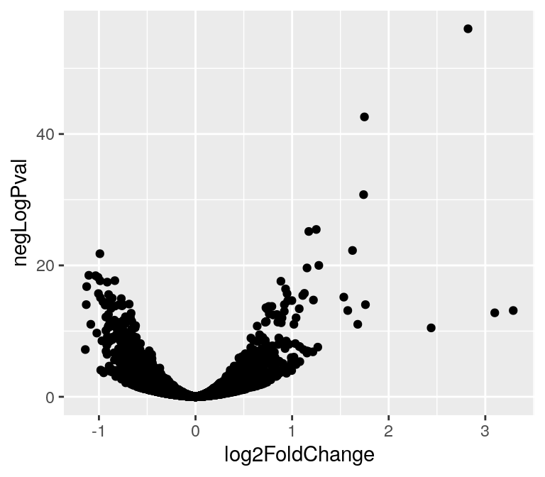

```r
> # calculate the y-axis data
> deg.df$negLogPval <- (-log10(deg.df$padj))
>
> ggplot(deg.df, aes(x = log2FoldChange, y = negLogPval)) + geom_point()
```

## Prepare the data frame for box plots

As shown above, box or bar plots usually display **categories at the x-axis**, e.g. treatment group or gene.

We have to introduce the categories into our data frame.

```r
> deg.df[1:5,c(1,3:8)]
##               id control_1 control_2 control_3      ko_1      ko_2      ko_3
## 1 WBGene00000001 3856.5403 3612.0591 3940.8629 4261.4508 4022.4646 3909.0812
## 2 WBGene00000002  153.4461  158.6615  137.2238  194.0029  182.1178  179.2724
## 3 WBGene00000003  306.8922  325.3565  313.0735  289.9021  285.7078  342.5046
## 4 WBGene00000004 1509.7808 1641.8451 1570.4496 1133.1535 1141.1603 1303.9706
## 5 WBGene00000005  101.9397  118.4940  100.6308  133.3770  125.3104  131.1519
>
> library("tidyr")
> deg.df.long <- pivot_longer(deg.df, cols= 3:8, names_to = "sample", values_to = "reads")
> head(deg.df.long , n=5)
## # A tibble: 5 x 7
##   id             symbol log2FoldChange  padj negLogPval sample    reads
##   <chr>          <chr>           <dbl> <dbl>      <dbl> <chr>     <dbl>
## 1 WBGene00000001 aap-1          0.0920 0.449      0.347 control_1 3857.
## 2 WBGene00000001 aap-1          0.0920 0.449      0.347 control_2 3612.
## 3 WBGene00000001 aap-1          0.0920 0.449      0.347 control_3 3941.
## 4 WBGene00000001 aap-1          0.0920 0.449      0.347 ko_1      4261.
## 5 WBGene00000001 aap-1          0.0920 0.449      0.347 ko_2      4022.
```

## Prepare the data frame for box plots

- Now we can use the columns `sample`, `group`, and `id` as categorial varibales of a box plot.
- For brevity, we select three genes by `id`

```r
> deg.df.long$group <- gsub("_.", "", deg.df.long$sample)
>
> deg.df.long[1:5,]
## # A tibble: 5 x 8
##   id             symbol log2FoldChange  padj negLogPval sample    reads group
##   <chr>          <chr>           <dbl> <dbl>      <dbl> <chr>     <dbl> <chr>
## 1 WBGene00000001 aap-1          0.0920 0.449      0.347 control_1 3857. control
## 2 WBGene00000001 aap-1          0.0920 0.449      0.347 control_2 3612. control
## 3 WBGene00000001 aap-1          0.0920 0.449      0.347 control_3 3941. control
## 4 WBGene00000001 aap-1          0.0920 0.449      0.347 ko_1      4261. ko
## 5 WBGene00000001 aap-1          0.0920 0.449      0.347 ko_2      4022. ko
>
> ddl.sel <- deg.df.long[deg.df.long$id %in% c("WBGene00000001","WBGene00000123","WBGene00007605"),]
> # %in% is the shortcut for match()
```

## Box plot

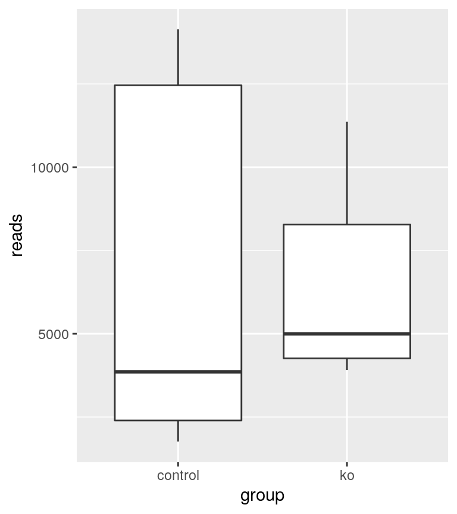

```r
ggplot(ddl.sel, aes(x = group, y = reads)) +
  geom_boxplot()
```

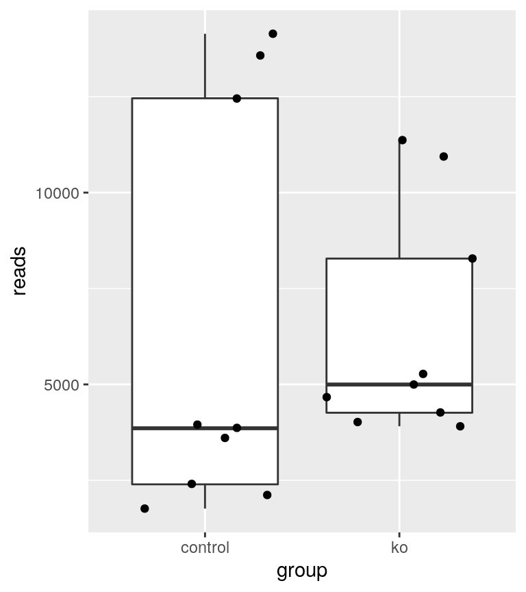

```r
ggplot(ddl.sel, aes(x = group, y = reads)) +
  geom_boxplot() + geom_jitter()
```

## Box plot

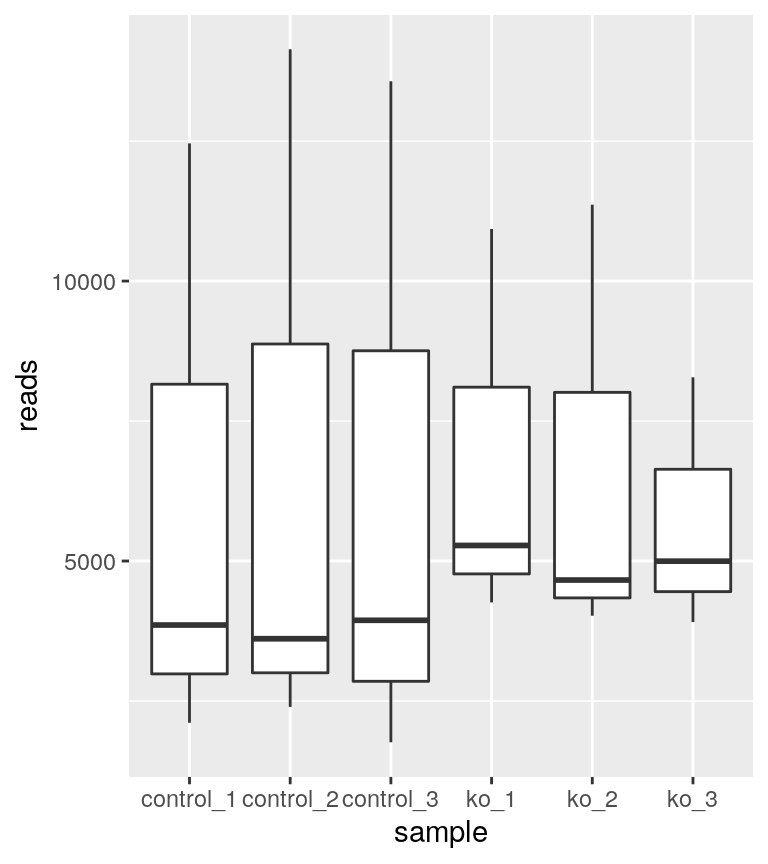

```r
ggplot(ddl.sel, aes(x = sample, y = reads)) +
  geom_boxplot()
```

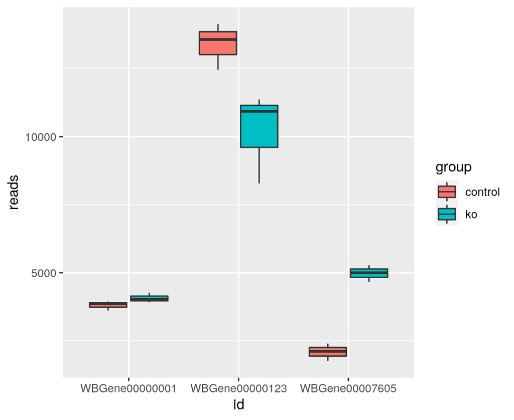

```r
ggplot(ddl.sel, aes(id, reads, fill = group)) +
  geom_boxplot()
```

## Faceting - divide a plot into subplots

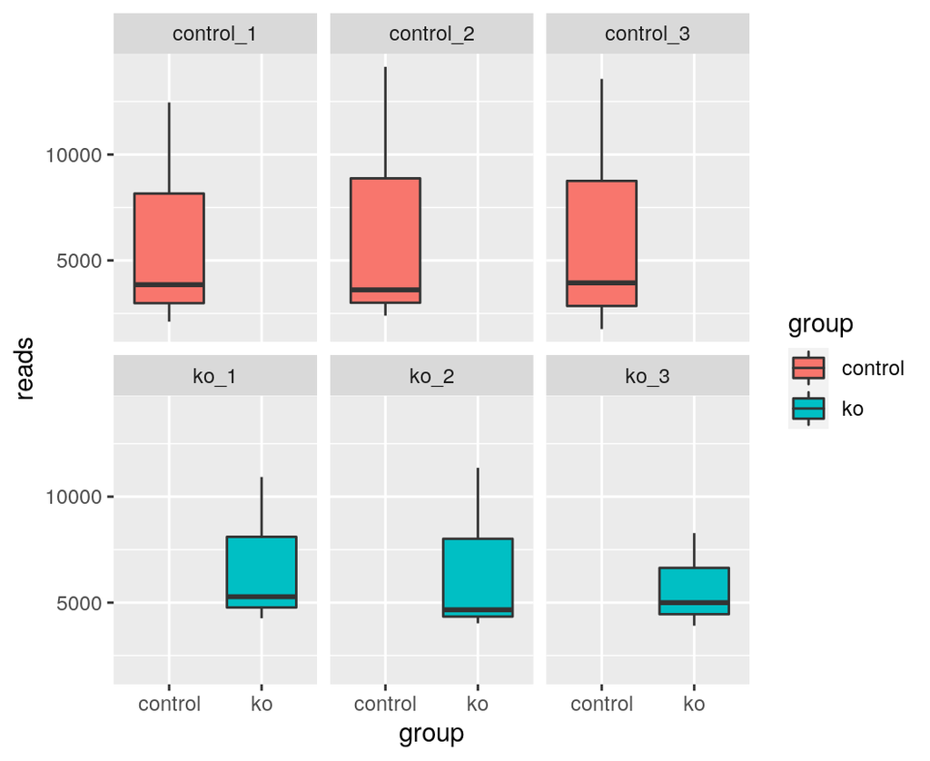

```r
ggplot(ddl.sel, aes(group, reads, fill=group)) +
  geom_boxplot() + facet_wrap(~sample)
```

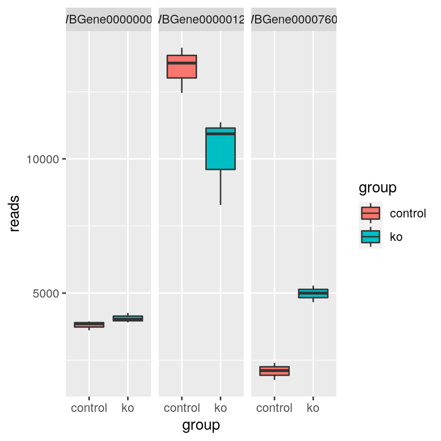

```r
ggplot(ddl.sel, aes(group, reads, fill=group)) +
  geom_boxplot() + facet_wrap(~id)
```

## Pretty Violin plot

We can highly customize our plots in ggplot2. It needs some practice. Again, the cheat sheets helps a lot to discover the possibilities.

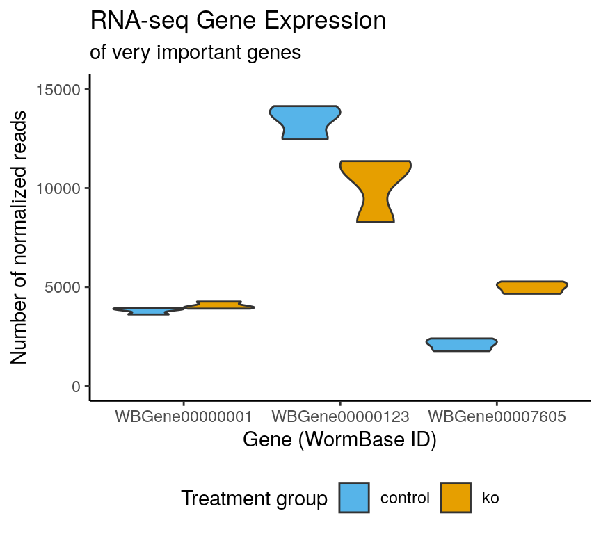

```r
p <- ggplot(ddl.sel, aes(id, reads, fill=group))+
  geom_violin(scale = "width")+
  labs(title = "RNA-seq Gene Expression",
       subtitle = "of very important genes",
       x = "Gene (WormBase ID)",
       y = "Number of normalized reads",
       fill = "Treatment group") +
  ylim(0,15000)+
  scale_fill_manual(values=c("#56B4E9","#E69F00"))+
  theme_classic()+
  theme(legend.position = "bottom")
```

## Pretty box plot

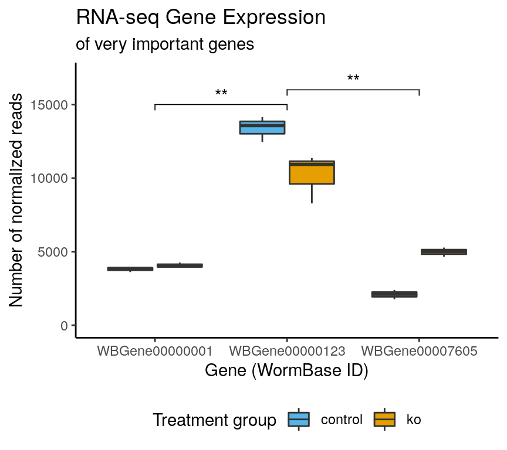

```r
#install.packages("ggpubr")
library("ggpubr") # install unless available

p <- ggplot(ddl.sel, aes(id, reads, fill=group))+
  geom_boxplot()+
  labs(title = "RNA-seq Gene Expression",
       subtitle = "of very important genes",
       x = "Gene (WormBase ID)",
       y = "Number of normalized reads",
       fill = "Treatment group") +
  ylim(0,17000)+
  scale_fill_manual(values=c("#56B4E9","#E69F00"))+
  theme_classic()+
  theme(legend.position = "bottom")+
  stat_compare_means(comparisons = list(
    c("WBGene00000001","WBGene00000123"),
    c("WBGene00000123","WBGene00007605")),
    label = "p.signif",
    label.y = c(15000, 16000),
    method = "wilcox.test", paired=F)
```

## Sample correlation heatmap

Find out how similar or different samples are based on their expression profile.

```r
> colnames(deg.df[,3:8])  # we only need the 6 columns with the expression values
## [1] "control_1" "control_2" "control_3" "ko_1"      "ko_2"      "ko_3"
>
> cor(deg.df[,3:8])       # pearson correation of all combinations
##           control_1 control_2 control_3      ko_1      ko_2      ko_3
## control_1 1.0000000 0.9998148 0.9988833 0.9988460 0.9949198 0.9876392
## control_2 0.9998148 1.0000000 0.9985918 0.9985118 0.9956390 0.9885905
## control_3 0.9988833 0.9985918 1.0000000 0.9988205 0.9968034 0.9913462
## ko_1      0.9988460 0.9985118 0.9988205 1.0000000 0.9962584 0.9908223
## ko_2      0.9949198 0.9956390 0.9968034 0.9962584 1.0000000 0.9976958
## ko_3      0.9876392 0.9885905 0.9913462 0.9908223 0.9976958 1.0000000
```

## Sample correlation heatmap

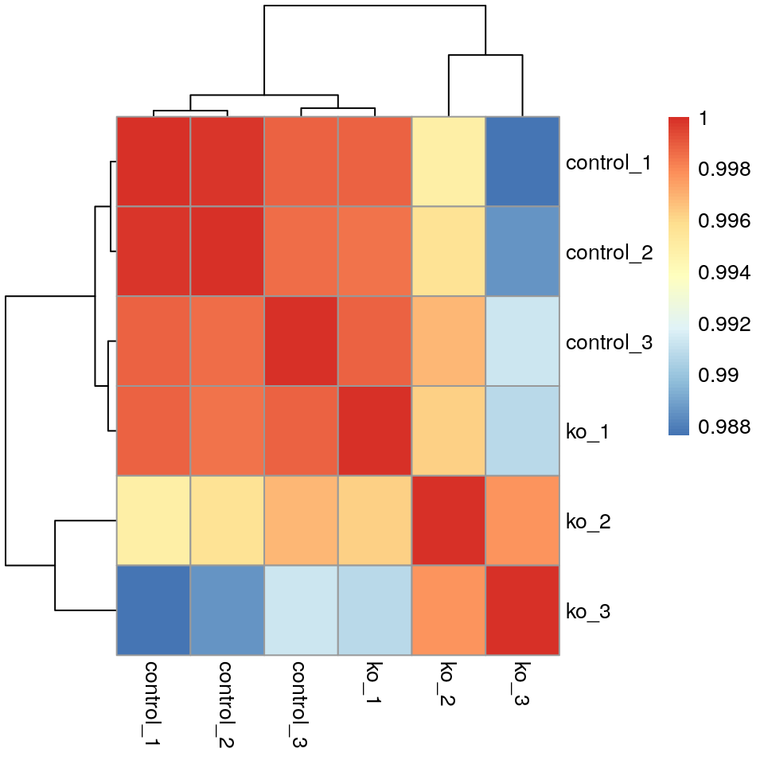

```r
> #install.packages("pheatmap")
> library("pheatmap")
> pheatmap(cor(deg.df[,3:8]))
```

## Storing figures as PDF

### Simple graphics

By surrounding the `barplot()` function by `pdf()` and `dev.off()` the figure is sent to a PDF file and not to the screen.

```r
> # store the figure in a pdf file
> pdf(file="animals_barplot.pdf")  # open the pdf
>
> barplot(animals$size, names.arg=animals$animal, main="Animal properties", ylab="Size (cm)")
>
> dev.off()                        # close the pdf
## png
##   2
```

## Storing figures as PDF

### ggplot2

ggplot2 has an own export function called `ggsave()`, the second argument is the plot itself.

```r
> p <- ggplot(ddl.sel, aes(group, reads, fill=group)) + geom_boxplot() + facet_wrap(~id)
> ggsave(filename = "export_boxplot.facet.pdf",  p)
```

## Storing figures as PDF

### pheatmap

pheatmap() has an argument for it: `filename =`

```r
> pheatmap(cor(deg.df[,3:8]), filename = "export_pheatmap.pdf")
```

## Data export

### Writing a data frame to xlsx & csv files

```r
> #install.packages("xlsx")
> #library(xlsx)
> #write.xlsx(deg.df.ord, file = "export_deg.df.ord.xlsx")
> # don't do this!
>
> # writing csv - csv can also be opend in Excel
> write.table(deg.df, file = "export_deg.df.csv", quote=FALSE, sep=",")
```

## Data normalization

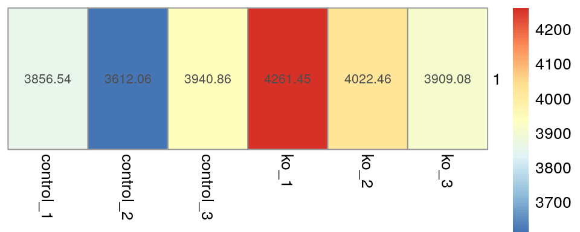

```r
> dd.1 <- deg.df[deg.df$id %in% c("WBGene00000001"),c(3:8)]
> pheatmap(dd.1, cluster_rows = F, cluster_cols = F, scale = "none", display_numbers = T)
```

## Data normalization

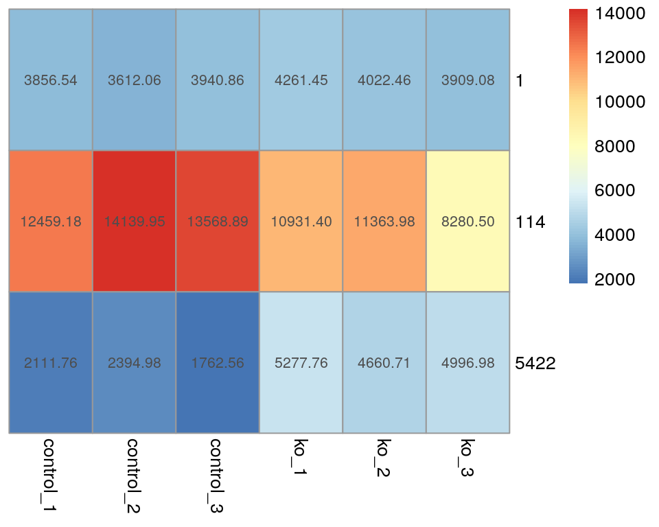

```r
> dd.3 <- deg.df[deg.df$id %in% c("WBGene00000001","WBGene00000123","WBGene00007605"),c(3:8)]
> pheatmap(dd.3, cluster_rows = F, cluster_cols = F, scale = "none", display_numbers = T)
```

## Data normalization

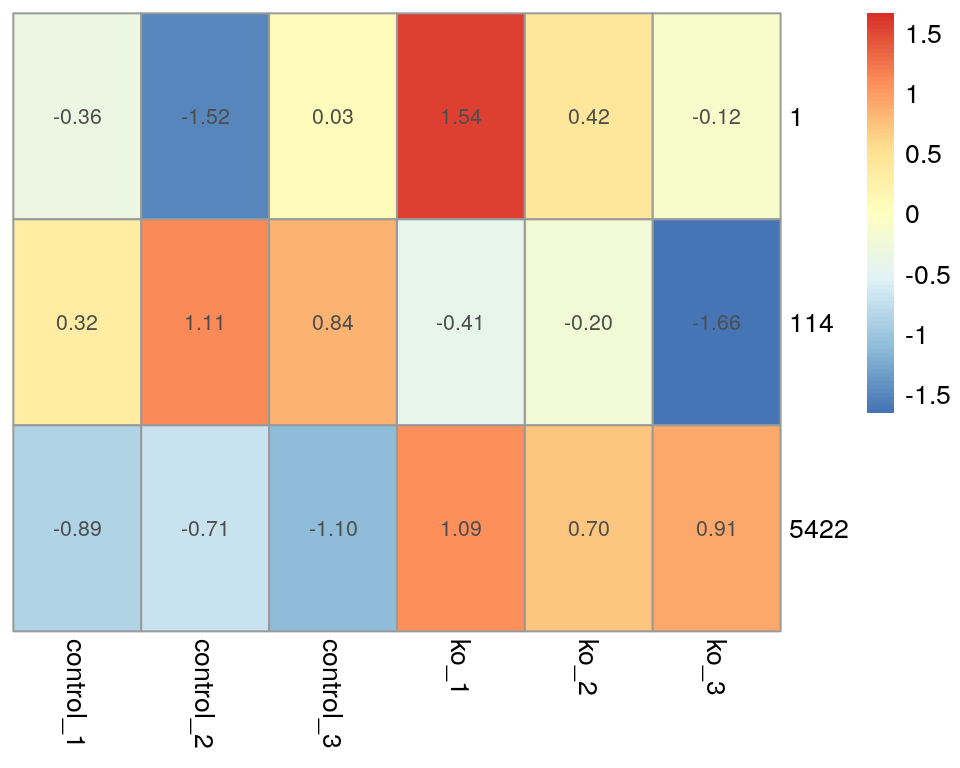

```r
> pheatmap(dd.3, cluster_rows = F, cluster_cols = F, scale = "row", display_numbers = T)
```

## Final feedback

multiple choice, one question

http://etc.ch/XtV8